# Untitled

NAME: Iñigo Oyarzun

First, we have to start importing the date from the library “mlbench”.

```r
library(mlbench)
data("PimaIndiansDiabetes")
```

With the function str we can easily know how many rows, observations or individuals we have (768) and how many variables we have. Also, we can check what kind of variables are in the dataset. Here we have 8 numeric variables and a factorial variable.

```r
str(PimaIndiansDiabetes)
```

```
## 'data.frame':    768 obs. of  9 variables:
##  $ pregnant: num  6 1 8 1 0 5 3 10 2 8 ...
##  $ glucose : num  148 85 183 89 137 116 78 115 197 125 ...
##  $ pressure: num  72 66 64 66 40 74 50 0 70 96 ...
##  $ triceps : num  35 29 0 23 35 0 32 0 45 0 ...
##  $ insulin : num  0 0 0 94 168 0 88 0 543 0 ...
##  $ mass    : num  33.6 26.6 23.3 28.1 43.1 25.6 31 35.3 30.5 0 ...
##  $ pedigree: num  0.627 0.351 0.672 0.167 2.288 ...
##  $ age     : num  50 31 32 21 33 30 26 29 53 54 ...
##  $ diabetes: Factor w/ 2 levels "neg","pos": 2 1 2 1 2 1 2 1 2 2 ...
```

Using the function summary we will see a quick descriptive statistics of the values in each variable.

```r
summary(PimaIndiansDiabetes)
```

```
##     pregnant         glucose         pressure         triceps
##  Min.   : 0.000   Min.   :  0.0   Min.   :  0.00   Min.   : 0.00
##  1st Qu.: 1.000   1st Qu.: 99.0   1st Qu.: 62.00   1st Qu.: 0.00
##  Median : 3.000   Median :117.0   Median : 72.00   Median :23.00
##  Mean   : 3.845   Mean   :120.9   Mean   : 69.11   Mean   :20.54
##  3rd Qu.: 6.000   3rd Qu.:140.2   3rd Qu.: 80.00   3rd Qu.:32.00
##  Max.   :17.000   Max.   :199.0   Max.   :122.00   Max.   :99.00
##     insulin           mass          pedigree           age        diabetes
##  Min.   :  0.0   Min.   : 0.00   Min.   :0.0780   Min.   :21.00   neg:500
##  1st Qu.:  0.0   1st Qu.:27.30   1st Qu.:0.2437   1st Qu.:24.00   pos:268
##  Median : 30.5   Median :32.00   Median :0.3725   Median :29.00
##  Mean   : 79.8   Mean   :31.99   Mean   :0.4719   Mean   :33.24
##  3rd Qu.:127.2   3rd Qu.:36.60   3rd Qu.:0.6262   3rd Qu.:41.00
##  Max.   :846.0   Max.   :67.10   Max.   :2.4200   Max.   :81.00
```

We can check that we have missing data because some numeric variables ($glucose, $pressure, $triceps, $insulin, $mass) have values equal to 0, but it doesn´t make sense in a biological context. We will characterize these values as missing data (NA) with the replace function

```r
PimaIndiansDiabetes[2:6] <- replace(PimaIndiansDiabetes[2:6],PimaIndiansDiabetes[2:6] == 0, NA)
```

We are able to make sure how many NA values we have in our dataset with the function is.na().

```r
summary(is.na(PimaIndiansDiabetes))
```

```
##   pregnant        glucose         pressure        triceps
##  Mode :logical   Mode :logical   Mode :logical   Mode :logical
##  FALSE:768       FALSE:763       FALSE:733       FALSE:541
##                  TRUE :5         TRUE :35        TRUE :227
##   insulin           mass          pedigree          age
##  Mode :logical   Mode :logical   Mode :logical   Mode :logical
##  FALSE:394       FALSE:757       FALSE:768       FALSE:768
##  TRUE :374       TRUE :11
##   diabetes
##  Mode :logical
##  FALSE:768
##
```

We also can check it using the summary function for our dataset again and we will see how the descriptive statistics have changed due to the missing data deletion.

```r
summary(PimaIndiansDiabetes)
```

```
##     pregnant         glucose         pressure         triceps
##  Min.   : 0.000   Min.   : 44.0   Min.   : 24.00   Min.   : 7.00
##  1st Qu.: 1.000   1st Qu.: 99.0   1st Qu.: 64.00   1st Qu.:22.00
##  Median : 3.000   Median :117.0   Median : 72.00   Median :29.00
##  Mean   : 3.845   Mean   :121.7   Mean   : 72.41   Mean   :29.15
##  3rd Qu.: 6.000   3rd Qu.:141.0   3rd Qu.: 80.00   3rd Qu.:36.00
##  Max.   :17.000   Max.   :199.0   Max.   :122.00   Max.   :99.00
##                   NA's   :5       NA's   :35       NA's   :227
##     insulin            mass          pedigree           age        diabetes
##  Min.   : 14.00   Min.   :18.20   Min.   :0.0780   Min.   :21.00   neg:500
##  1st Qu.: 76.25   1st Qu.:27.50   1st Qu.:0.2437   1st Qu.:24.00   pos:268
##  Median :125.00   Median :32.30   Median :0.3725   Median :29.00
##  Mean   :155.55   Mean   :32.46   Mean   :0.4719   Mean   :33.24
##  3rd Qu.:190.00   3rd Qu.:36.60   3rd Qu.:0.6262   3rd Qu.:41.00
##  Max.   :846.00   Max.   :67.10   Max.   :2.4200   Max.   :81.00
##  NA's   :374      NA's   :11
```

Now we will use some graphical tools to explore our data.

HISTOGRAMS

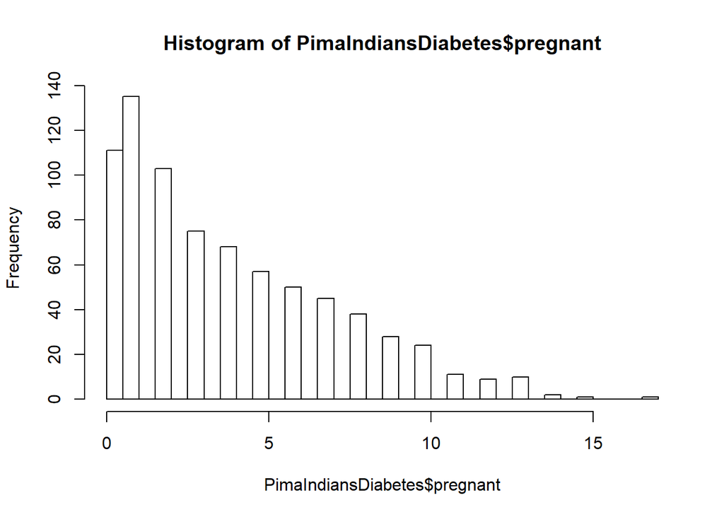

```r
hist(PimaIndiansDiabetes$pregnant,25)
```

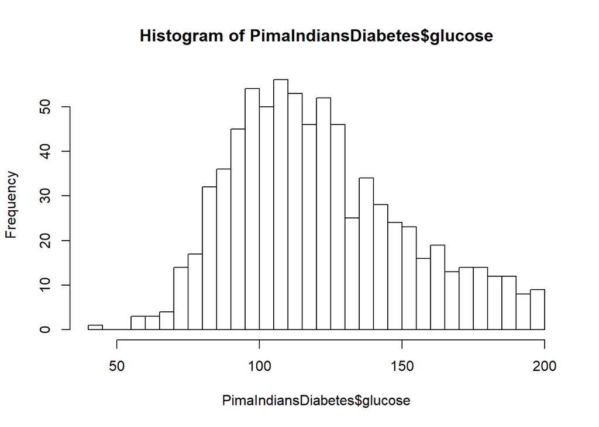

```r
hist(PimaIndiansDiabetes$glucose,25)
```

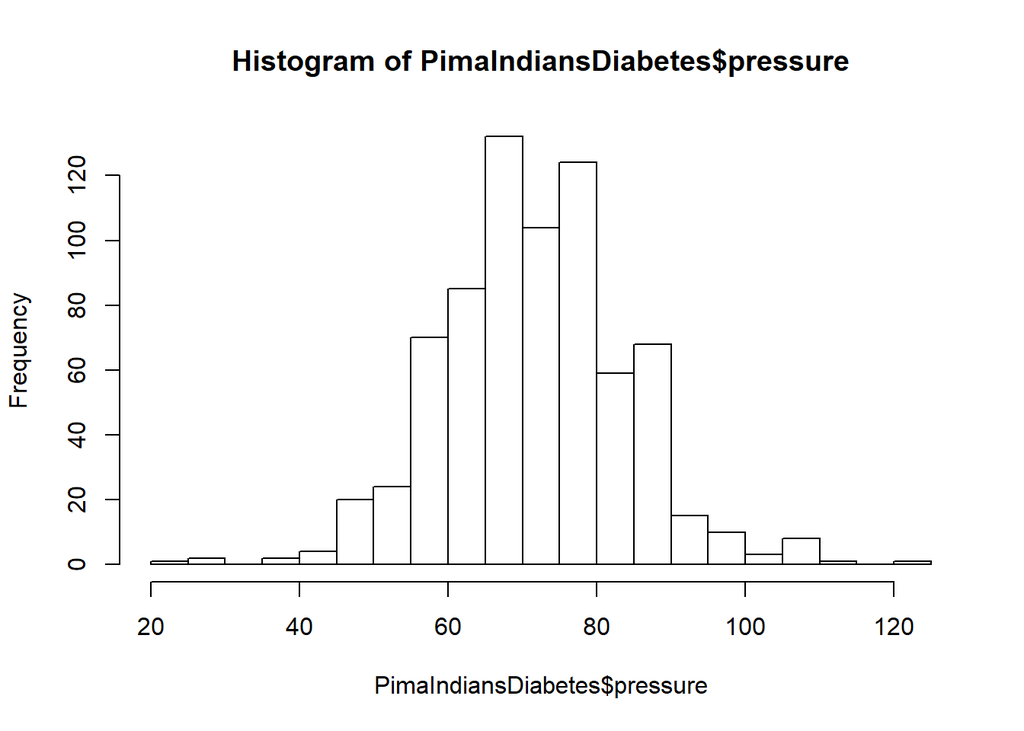

```r
hist(PimaIndiansDiabetes$pressure,25)
```

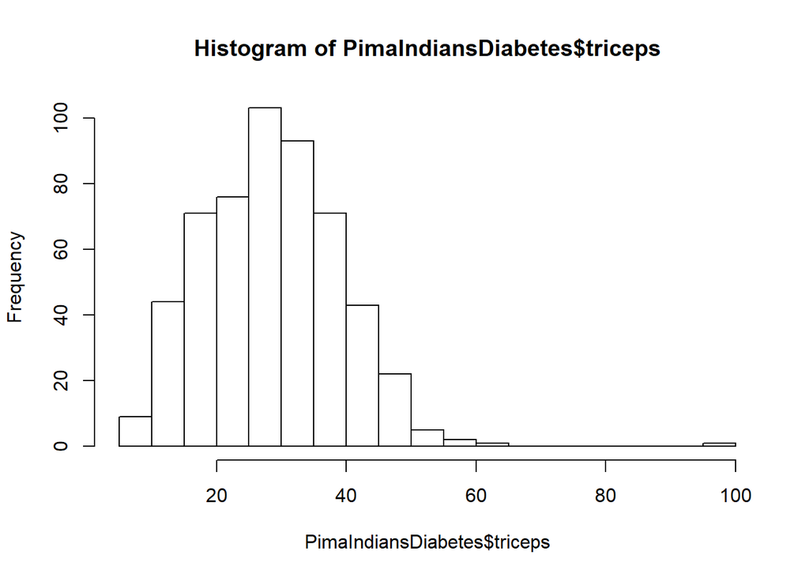

```r
hist(PimaIndiansDiabetes$triceps,25)
```

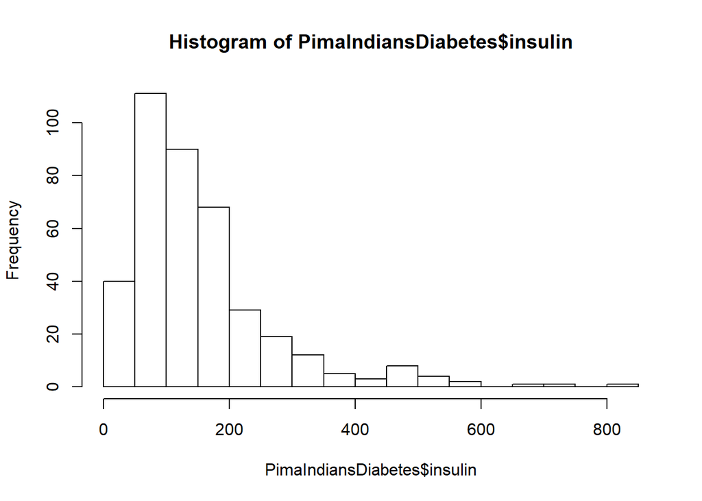

```r
hist(PimaIndiansDiabetes$insulin,25)
```

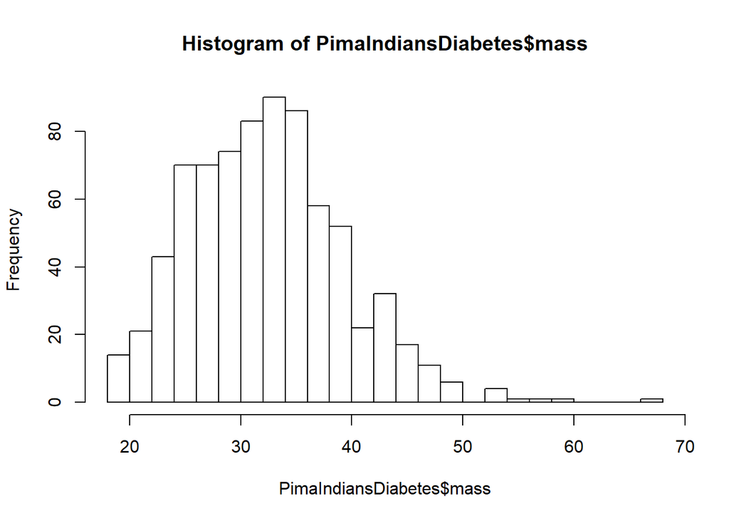

```r
hist(PimaIndiansDiabetes$mass,25)
```

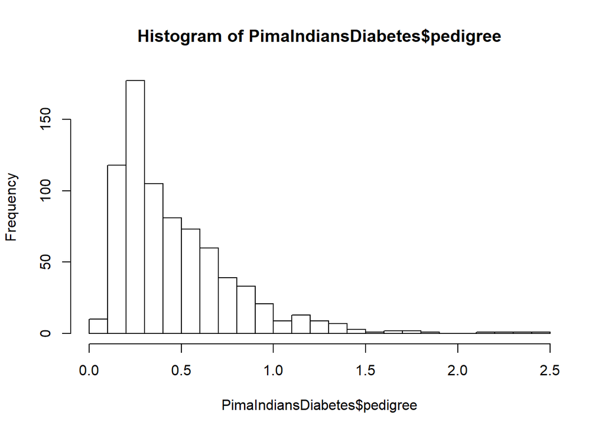

```r
hist(PimaIndiansDiabetes$pedigree,25)
```

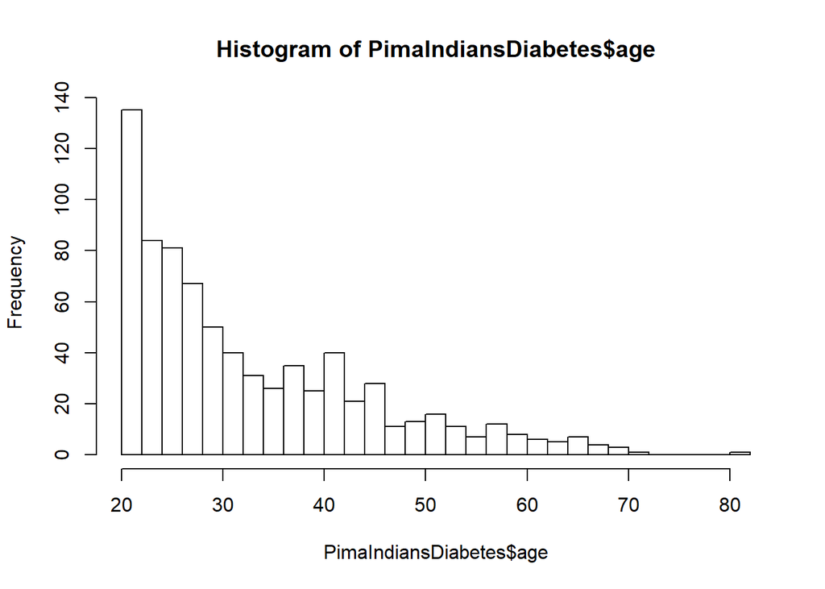

```r
hist(PimaIndiansDiabetes$age,25)
```

Using these histograms, we can see that the variables $pregnant, $glucose, $insulin, $mass, $pedigree and $age are positive skew, we could reduce this skew by using the log or square root of these variables. Also we can appreciate that the variables $pressure and $triceps, apparently follow a normal distribution.

PLOTS

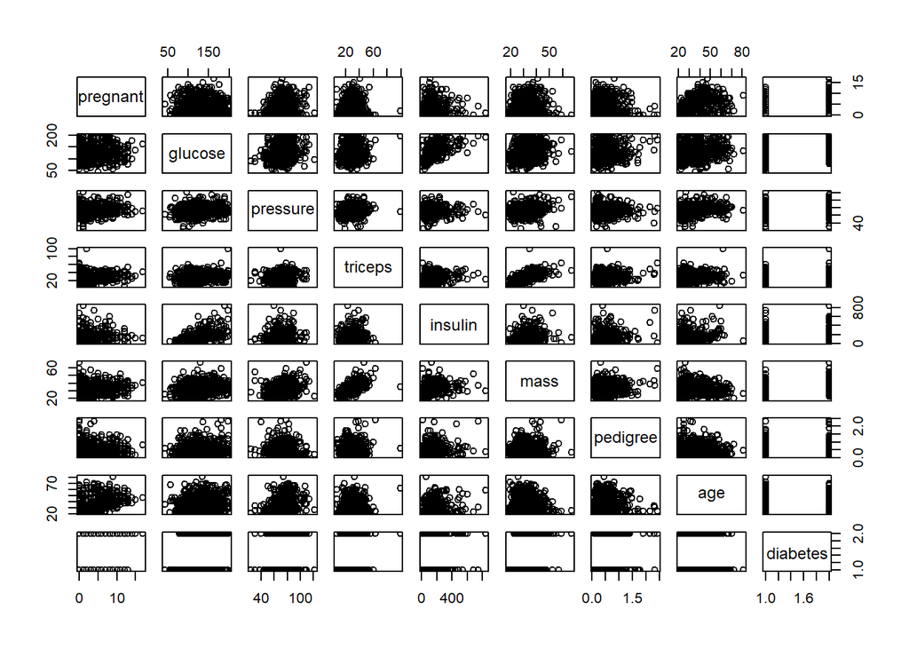

```r
pairs(PimaIndiansDiabetes)
```

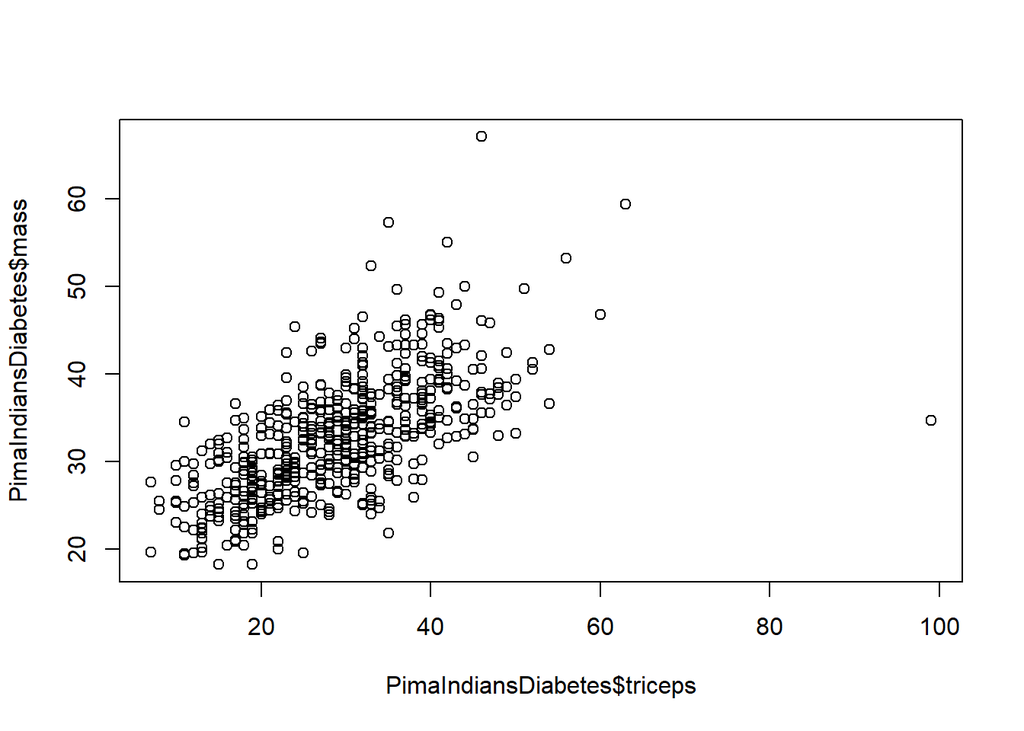

```r
plot(PimaIndiansDiabetes$triceps,PimaIndiansDiabetes$mass)
```

Using the first command we received all the plots that we can do between our variables. From this overview we saw that the variables $triceps and $mass could have some kind of correlation so we plot them in a bigger graphic with the second command and decide to make a lineal regression of them with the lm() function.

```r
summary(lm(PimaIndiansDiabetes$triceps~PimaIndiansDiabetes$mass))
```

```
##
## Call:
## lm(formula = PimaIndiansDiabetes$triceps ~ PimaIndiansDiabetes$mass)
##
## Residuals:
##     Min      1Q  Median      3Q     Max
## -19.764  -5.068  -0.612   5.021  68.038
##
## Coefficients:
##                          Estimate Std. Error t value Pr(>|t|)
## (Intercept)              -3.37349    1.68557  -2.001   0.0459 *
## PimaIndiansDiabetes$mass  0.98948    0.05016  19.727   <2e-16 ***
## ---
## Signif. codes:  0 '***' 0.001 '**' 0.01 '*' 0.05 '.' 0.1 ' ' 1
##
## Residual standard error: 7.995 on 537 degrees of freedom
##   (229 observations deleted due to missingness)
## Multiple R-squared:  0.4202, Adjusted R-squared:  0.4191
## F-statistic: 389.2 on 1 and 537 DF,  p-value: < 2.2e-16
```

Looking at the adjusted R-squared we see that its just 0,4191 so the predictive power of this model is not good enough.

BOXPLOTS

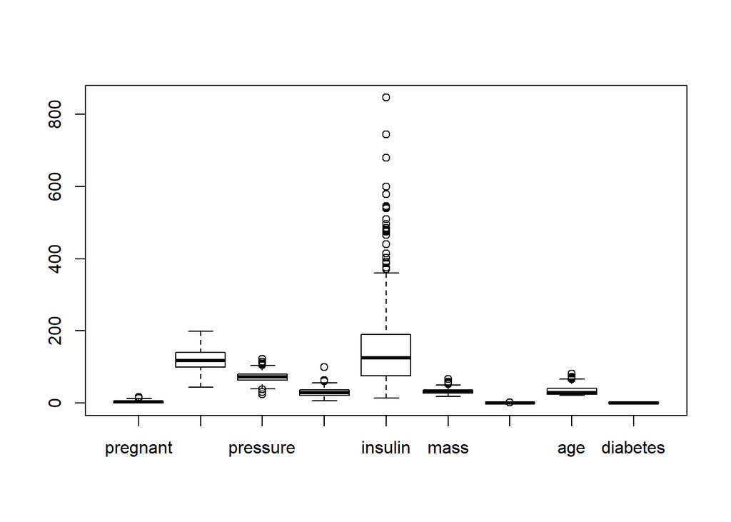

```r
boxplot(PimaIndiansDiabetes)
```

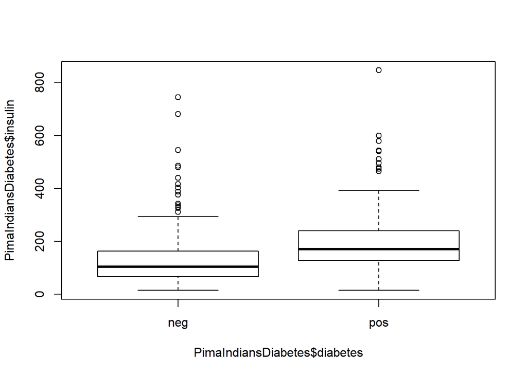

```r
boxplot(PimaIndiansDiabetes$insulin~PimaIndiansDiabetes$diabetes)
```

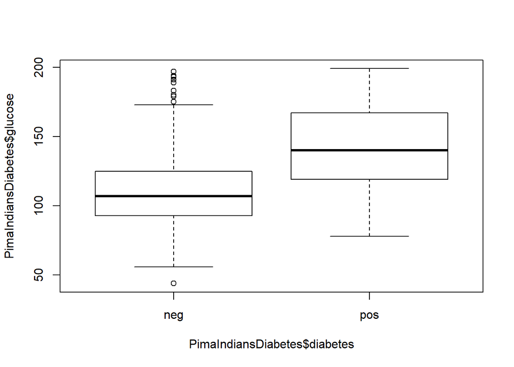

```r
boxplot(PimaIndiansDiabetes$glucose~PimaIndiansDiabetes$diabetes)
```

In the first graphic we can see the boxplots of each variable, also check that the variable $insulin have many outliers.

We were interested in compare the boxplots for variables $glucose and $insulin differenciating between people with diabetes and people without diabetes. As we can see in the boxplots, women with diabetes use to have more glucose and also more insulin.

```r
 PimaIndiansDiabetes$glucose[is.na(PimaIndiansDiabetes$glucose)]<-117
 PimaIndiansDiabetes$pressure[is.na(PimaIndiansDiabetes$pressure)]<-72.41
 PimaIndiansDiabetes$triceps[is.na(PimaIndiansDiabetes$triceps)]<-29.15
 PimaIndiansDiabetes$insulin[is.na(PimaIndiansDiabetes$insulin)]<-155.55
 PimaIndiansDiabetes$mass[is.na(PimaIndiansDiabetes$mass)]<-32.46
```

Fixing these data we will be able to check the correlation of the different variables with the next commands.

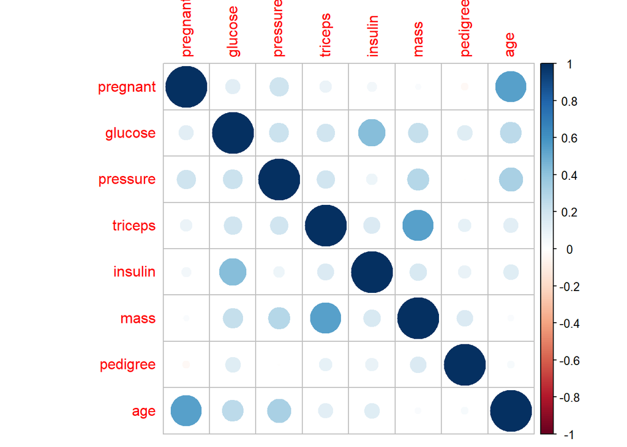

```r
correlation<-cor(PimaIndiansDiabetes[c(1,2,3,4,5,6,7,8)])
library(corrplot)
corrplot(correlation)
```

Also, with the goal of building any statistical model (for example a logistic regression) we could change the factorial variable $diabetes for a numeric variable, neg will be 0 and pos will be 1.

```r
PimaIndiansDiabetes$diabetes<-as.numeric(PimaIndiansDiabetes$diabetes)
PimaIndiansDiabetes$diabetes <- replace(PimaIndiansDiabetes$diabetes,PimaIndiansDiabetes$diabetes == 1, 0)
PimaIndiansDiabetes$diabetes <- replace(PimaIndiansDiabetes$diabetes,PimaIndiansDiabetes$diabetes == 2, 1)
```